# Customer Segmentation

Sanjay Renduchintala (vrenduch)

### 0. Problem Summary

(.) 1. Develop an **attrition model**, to predict whether a customer will cancel their subscription in the near future. Characterize your model performance. (.) 2. Develop a model for estimating the **ltv** of a customer. Characterize your model performance. (✓) 3. Develop a **customer segmentation** scheme. Include in this scheme the identification of sleeping customers, those that are no longer active but have not canceled their account.

#### About the dataset:

- id: A unique user identifier
- status: Subscription status:‘0’- new, ‘1’- open, ‘2’- cancelation event
- gender: User gender ‘M’- male ‘F’- female
- date: Date of in which user ‘id’ logged into the site
- pages: Number of pages visted by user ‘id’ on date ‘date’
- onsite: Number of minutes spent on site by user ‘id’ on date ‘date’
- entered: Flag indicating whether or not user entered the send order path on date ‘date’
- completed: Flag indicating whether the user completed the order (sent an eCard)
- holiday: Flag indicating whether at least one completed order included a holiday themed card

```r
# Import libraries
library(plyr)
library(ggplot2)
library(dplyr)
library(reshape2)
library(cluster)
library(factoextra)
```

### 1. Exploratory Data Analysis

```r
ltv.data <- read.csv('ltv.csv')
head(ltv.data)
```

```
##   id status gender     date pages onsite entered completed holiday
## 1  1      0      M 31/10/14     7      3       1         1       0
## 2  1      1      M 01/11/14     6      8       0         0       0
## 3  1      1      M 02/11/14     6     20       1         0       0
## 4  1      1      M 15/12/14     1      1       0         0       0
## 5  1      1      M 19/12/14     1      1       0         0       0
## 6  1      2      M 23/12/14     0      0       0         0       0
```

```r
ltv.data <- ltv.data %>% mutate_at(vars(id, status, gender, entered, completed, holiday), funs(as.factor(.)))
ltv.data$date <- as.Date(ltv.data$date, '%d/%m/%y')
summary(ltv.data)
```

```
##        id         status     gender          date                pages
##  2480   :   166   0: 10000   F:358716   Min.   :2011-01-01   Min.   : 0.000
##  1176   :   157   1:387518   M: 45119   1st Qu.:2012-06-29   1st Qu.: 3.000
##  8405   :   156   2:  6317              Median :2013-05-04   Median : 5.000
##  3390   :   153                         Mean   :2013-04-10   Mean   : 5.018
##  5450   :   152                         3rd Qu.:2014-01-26   3rd Qu.: 7.000
##  5973   :   151                         Max.   :2014-12-31   Max.   :10.000
##  (Other):402900
##      onsite        entered    completed  holiday
##  Min.   :  0.000   0: 88011   0:176577   0:311882
##  1st Qu.:  2.000   1:315824   1:227258   1: 91953
##  Median :  5.000
##  Mean   :  8.831
##  3rd Qu.: 11.000
##  Max.   :220.000
##
```

#### 1.1. Missing values

```r
sapply(ltv.data, function(x) sum(is.na(x)))
```

```
##        id    status    gender      date     pages    onsite   entered completed
##         0         0         0         0         0         0         0         0
##   holiday
##         0
```

**Observation:** There are no missing values in the data

#### 1.2. Extreme values

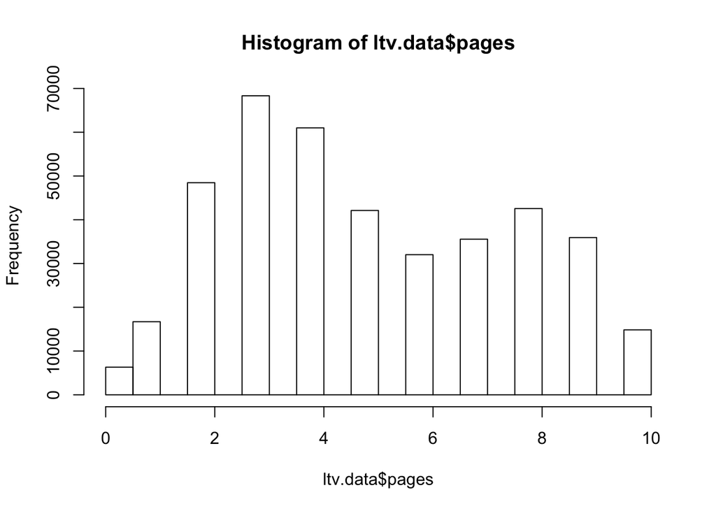

```r
hist(ltv.data$pages)
```

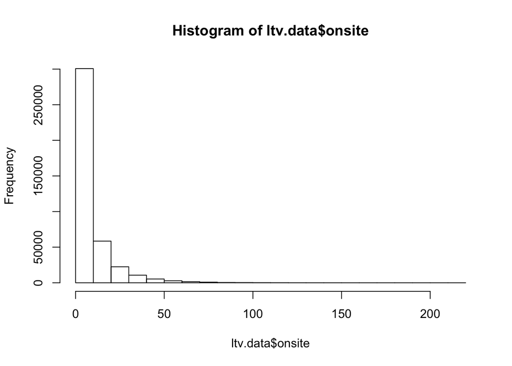

```r
hist(ltv.data$onsite)
```

**Observation**: ‘Onsite’ has some extreme values

```r
# Quantiles
quantile(ltv.data$onsite, c(0,.1,.25,.5,.75,.9,.95,.99,1))
```

```
##   0%  10%  25%  50%  75%  90%  95%  99% 100%
##    0    1    2    5   11   22   32   57  220
```

**Action:** Cap observations where user has spent more than 60 minutes on the website to 60 minutes

#### 1.3. Cap obervations where user spent more then 60 minutes to 60 minutes

```r
ltv.data[ltv.data$onsite>60,"onsite"] <- 60
summary(ltv.data)
```

```
##        id         status     gender          date                pages
##  2480   :   166   0: 10000   F:358716   Min.   :2011-01-01   Min.   : 0.000
##  1176   :   157   1:387518   M: 45119   1st Qu.:2012-06-29   1st Qu.: 3.000
##  8405   :   156   2:  6317              Median :2013-05-04   Median : 5.000
##  3390   :   153                         Mean   :2013-04-10   Mean   : 5.018
##  5450   :   152                         3rd Qu.:2014-01-26   3rd Qu.: 7.000
##  5973   :   151                         Max.   :2014-12-31   Max.   :10.000
##  (Other):402900
##      onsite       entered    completed  holiday
##  Min.   : 0.000   0: 88011   0:176577   0:311882
##  1st Qu.: 2.000   1:315824   1:227258   1: 91953
##  Median : 5.000
##  Mean   : 8.686
##  3rd Qu.:11.000
##  Max.   :60.000
##
```

#### 1.4. Gender and Tenure

```r
# Number of users
print(paste0("Number of users: " , n_distinct(ltv.data$id)))
```

```
## [1] "Number of users: 10000"
```

```r
# Number of users by gender
print("Users by gender:")
```

```
## [1] "Users by gender:"
```

```r
print.data.frame(ltv.data %>% group_by(gender) %>% summarise(count = n_distinct(id)))
```

```
##   gender count
## 1      F  7924
## 2      M  2076
```

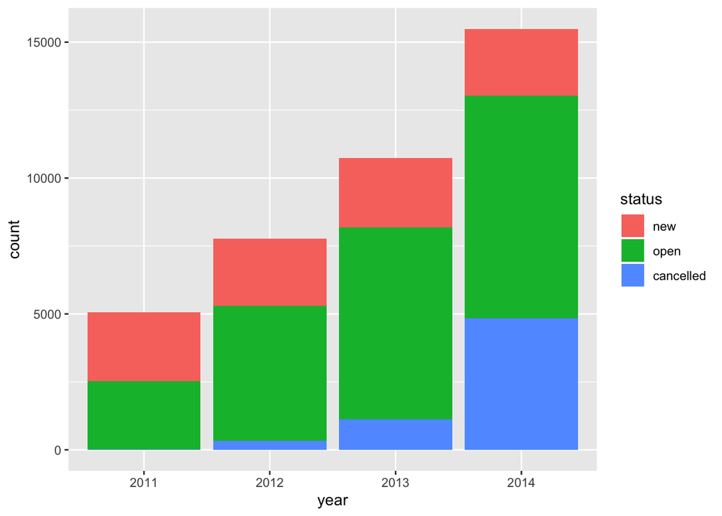

```r
# Attrition
att.summ <- ltv.data %>% mutate(month = format(date, "%m"), year = format(date, "%Y")) %>% group_by(year, status) %>% summarise(count = n_distinct(id))

att.summ$status <- mapvalues(att.summ$status,
          from=c(0,1,2),
          to=c("new","open","cancelled"))

ggplot(att.summ, aes(x = year, y = count,fill=status)) +
    geom_bar(stat='identity')
```

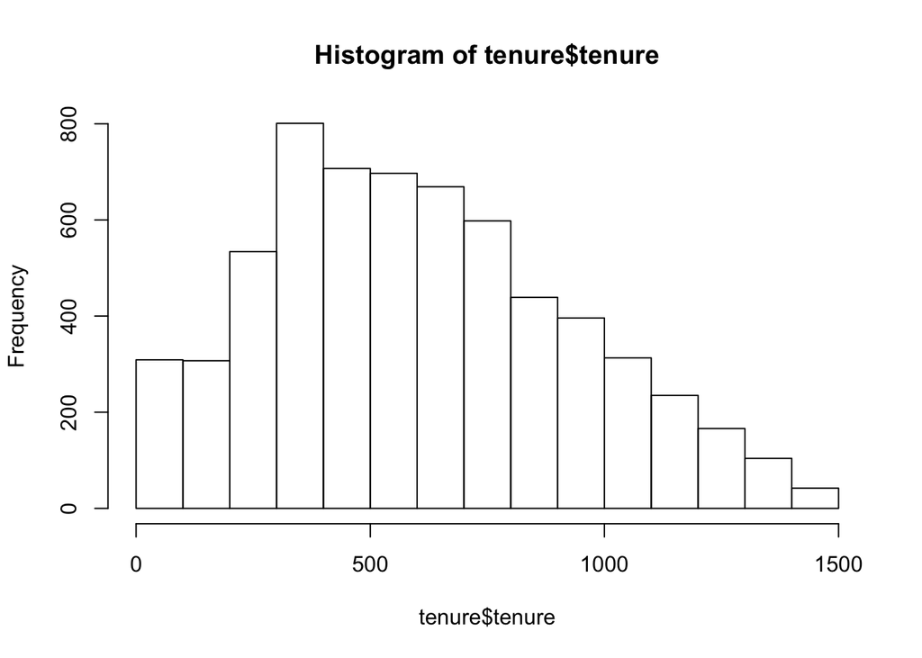

```r
# Customer tenure
tenure <- dcast(ltv.data[ltv.data$status != 1,], id ~ status, value.var = 'date')
tenure[,2] <- as.Date(tenure[,2],origin = "1970-01-01")
tenure[,3] <- as.Date(tenure[,3], origin = "1970-01-01")
tenure$tenure <- as.integer(tenure[,3] - tenure[,2])
hist(tenure$tenure)
```

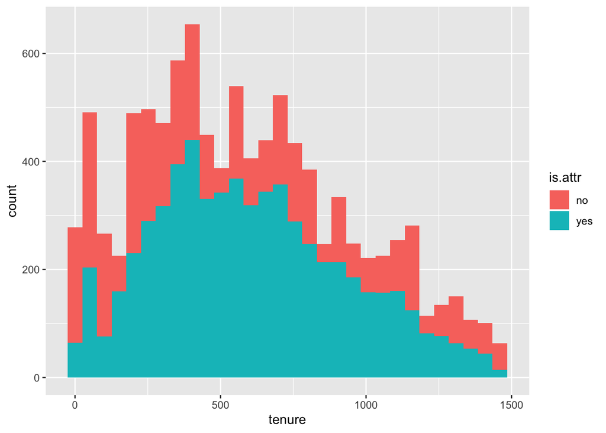

```r
tenure$is.attr <- "yes"
tenure[is.na(tenure$tenure),]$is.attr <- "no"
tenure[is.na(tenure$tenure),]$tenure <- as.Date("2014-12-31") - tenure[is.na(tenure$tenure),2]
tenure[is.na(tenure$tenure),]$tenure <- tenure[is.na(tenure$tenure),3] - as.Date("2011-01-01")
tenure %>%
  ggplot(aes(x = tenure, fill = is.attr))+
  geom_histogram(position = "stack")
```

```r
summary(tenure$tenure)
```

```
##    Min. 1st Qu.  Median    Mean 3rd Qu.    Max.
##       0     312     545     586     826    1460
```

```r
tapply(tenure$tenure, tenure$is.attr, summary)
```

```
## $no
##    Min. 1st Qu.  Median    Mean 3rd Qu.    Max.
##     1.0   199.0   443.0   553.7   853.5  1460.0
##
## $yes
##    Min. 1st Qu.  Median    Mean 3rd Qu.    Max.
##     0.0   360.0   569.0   604.8   822.0  1457.0
```

### 2. Feature engineering

```r
# List of cancelled customers
attr.list <- ltv.data %>% group_by(id) %>% summarise(final.status = max(as.integer(as.character(status))))
attr.list <- attr.list$id[attr.list$final.status == 2]
```

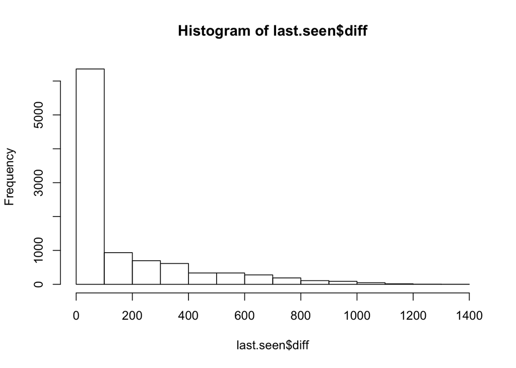

```r
# Last seen

last.seen <- ltv.data %>% group_by(id) %>% summarise(diff= as.integer(as.Date("31/12/2014", "%d/%m/%Y")- max(date)))

hist(last.seen$diff)
```

```r
# Interarrival time
ltv.data.copy <- ltv.data[order(ltv.data$id, ltv.data$date),]
ltv.data.copy <- ltv.data.copy[!(ltv.data.copy$id %in% attr.list),]
ltv.data.copy$id.lag <- lag(ltv.data.copy$id,1)
ltv.data.copy$date.lag <- lag(ltv.data.copy$date,1)
ltv.data.copy$time.since.last.event <- ltv.data.copy$date - ltv.data.copy$date.lag
ltv.data.copy$time.since.last.event[ltv.data.copy$id != ltv.data.copy$id.lag] <- NA

frequency <- ltv.data.copy %>% group_by(id) %>% summarise(last.seen.days= as.integer(as.Date("31/12/2014", "%d/%m/%Y")- max(date)), last.seen = max(date),
                                                          num.freq = length(which(!is.na(time.since.last.event))),
                                                          min.freq = as.integer(min(time.since.last.event, na.rm = TRUE)),
                                                          max.freq = as.integer(max(time.since.last.event, na.rm = TRUE)),
                                                          q1.freq = as.integer(quantile(time.since.last.event, probs = 0.25,na.rm = TRUE)),
                                                          q3.freq = as.integer(quantile(time.since.last.event, probs = 0.75,na.rm = TRUE)),
                                                          avg.freq = as.integer(mean(time.since.last.event, na.rm = TRUE)),
                                                          perctentile.last.seen = sum(time.since.last.event <= last.seen.days,
                                                                                      na.rm = TRUE)/length(which(!is.na(time.since.last.event))))
frequency <- merge(x= frequency, y = tenure[,c('id', 'tenure')], by= 'id', all.x = TRUE)
summary(frequency)
```

```
##        id       last.seen.days      last.seen             num.freq
##  3      :   1   Min.   :   0.00   Min.   :2011-12-23   Min.   :  0.0
##  4      :   1   1st Qu.:   7.00   1st Qu.:2014-12-17   1st Qu.: 14.0
##  6      :   1   Median :  10.00   Median :2014-12-21   Median : 29.0
##  7      :   1   Mean   :  43.37   Mean   :2014-11-17   Mean   : 40.3
##  10     :   1   3rd Qu.:  14.00   3rd Qu.:2014-12-24   3rd Qu.: 59.0
##  11     :   1   Max.   :1104.00   Max.   :2014-12-31   Max.   :165.0
##  (Other):3677
##     min.freq         max.freq        q1.freq          q3.freq
##  Min.   : 1.000   Min.   :  1.0   Min.   : 1.000   Min.   :  1.0
##  1st Qu.: 1.000   1st Qu.: 40.0   1st Qu.: 1.000   1st Qu.: 12.0
##  Median : 1.000   Median : 60.0   Median : 2.000   Median : 15.0
##  Mean   : 1.052   Mean   : 72.9   Mean   : 2.535   Mean   : 16.7
##  3rd Qu.: 1.000   3rd Qu.: 91.0   3rd Qu.: 3.000   3rd Qu.: 20.0
##  Max.   :57.000   Max.   :657.0   Max.   :83.000   Max.   :168.0
##  NA's   :2        NA's   :2       NA's   :2        NA's   :2
##     avg.freq      perctentile.last.seen     tenure
##  Min.   :  1.00   Min.   :0.0000        Min.   :   1.0
##  1st Qu.:  9.00   1st Qu.:0.5054        1st Qu.: 199.0
##  Median : 11.00   Median :0.6615        Median : 443.0
##  Mean   : 12.63   Mean   :0.6479        Mean   : 553.7
##  3rd Qu.: 15.00   3rd Qu.:0.8667        3rd Qu.: 853.5
##  Max.   :114.00   Max.   :1.0000        Max.   :1460.0
##  NA's   :2        NA's   :2
```

### 3. Clustering

#### 3.1. Hierarchical Clustering

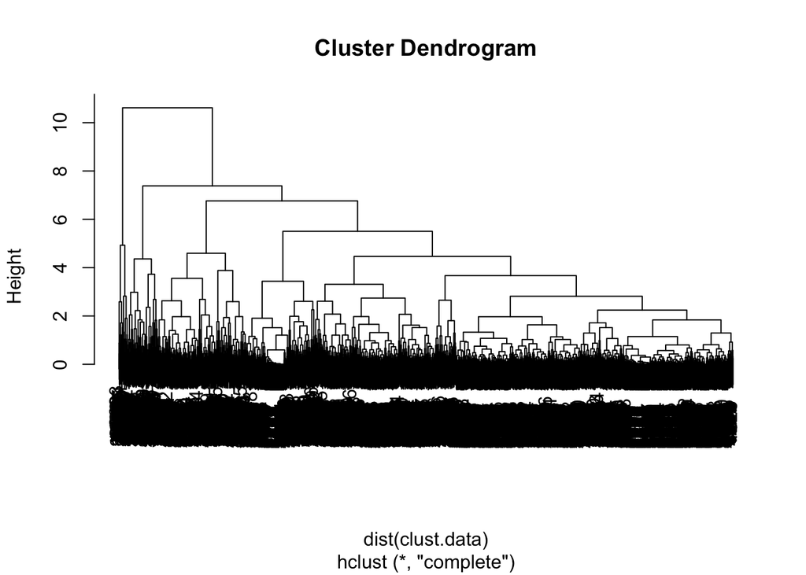

```r
frequency <- na.omit(frequency)
clust.data <- scale(frequency[,c(2,4,10,11)])
clusters <- hclust(dist(clust.data))
plot(clusters)
```

```r
# Split to 10 groups and compare groups
frequency$hclust.groups <- cutree(clusters, k=10)
```

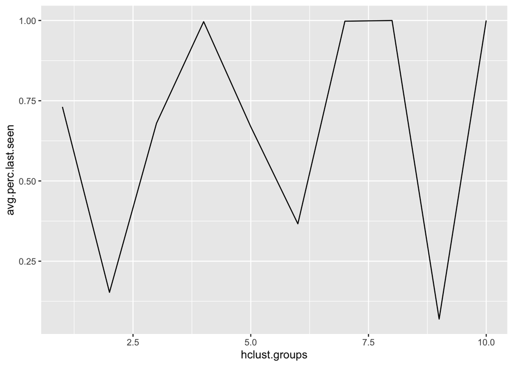

```r
agg.data <- frequency %>% group_by(hclust.groups) %>% summarise(avg.perc.last.seen = mean(perctentile.last.seen, na.rm = TRUE),
                                                             avg.last.seen.days = mean(last.seen.days), na.rm = TRUE,
                                                             avg.tenure = mean(tenure, na.rm = TRUE),
                                                             avg.total.freq = mean(num.freq, na.rm = TRUE))
ggplot(agg.data, aes(x=hclust.groups, y= avg.perc.last.seen)) +
  geom_line()
```

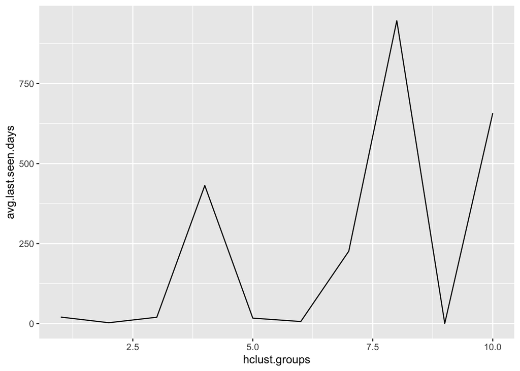

```r
ggplot(agg.data, aes(x=hclust.groups, y= avg.last.seen.days)) +
  geom_line()
```

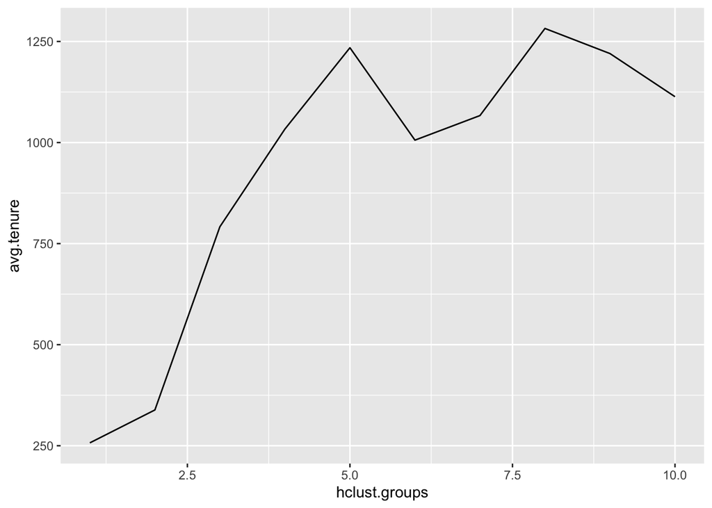

```r
ggplot(agg.data, aes(x=hclust.groups, y= avg.tenure)) +
  geom_line()
```

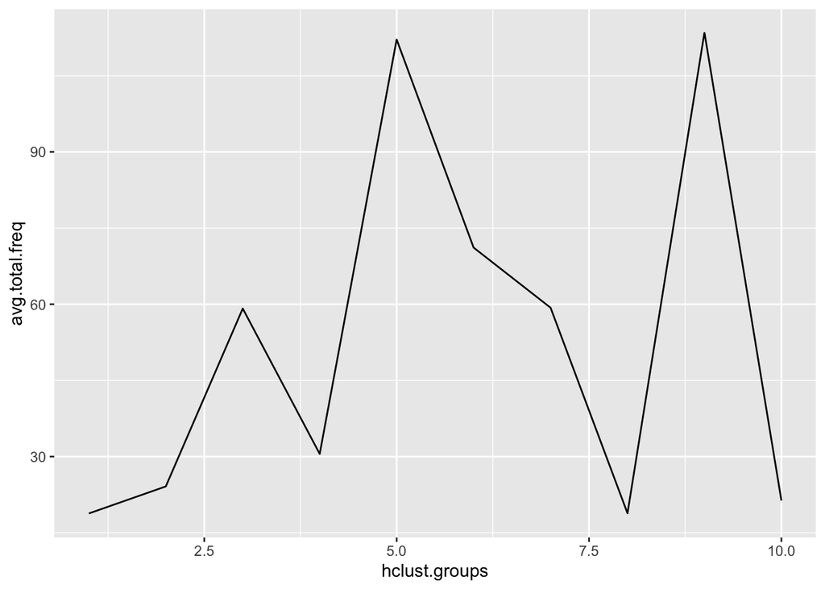

```r
ggplot(agg.data, aes(x=hclust.groups, y= avg.total.freq)) +
  geom_line()
```

Observation: There are groups with distinct features emerging from the analysis but some groups maybe sparsely populated

```r
frequency %>% group_by(hclust.groups) %>% summarise(n= length(id)) %>% arrange(desc(n))
```

```
## # A tibble: 10 x 2
##    hclust.groups     n
##            <int> <int>
##  1             1  1786
##  2             3   720
##  3             2   412
##  4             5   347
##  5             6   155
##  6             7   104
##  7             4    76
##  8            10    33
##  9             8    24
## 10             9    24
```

Obervation: There are six groups with more than 100 observations; top 3 groups cover ~80% and top 4 cover ~90% of the ids

#### 3.2. Mean Shift

```r
library(meanShiftR)
ms.result <- meanShift(na.omit(clust.data))
frequency$ms.groups <- ms.result$assignment
```

```r
frequency %>% group_by(ms.groups)  %>% summarise(n= length(id)) %>% arrange(desc(n))
```

```
## # A tibble: 79 x 2
##    ms.groups     n
##        <dbl> <int>
##  1         1  2367
##  2         2   588
##  3         5   174
##  4         3    93
##  5         8    73
##  6        10    67
##  7        14    44
##  8        18    41
##  9        20    34
## 10        16    29
## # … with 69 more rows
```

Observation: Top 3 groups contain ~85% of the ids

#### 3.3. K-means clustering and selection of K

```r
clust.data <- scale(frequency[,c(2,4,9,10,11)])
```

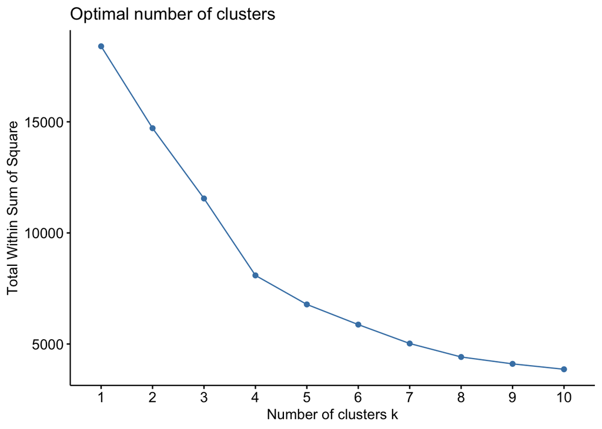

```r
# Elbow method using sum of squares
fviz_nbclust(clust.data, kmeans, method = "wss")
```

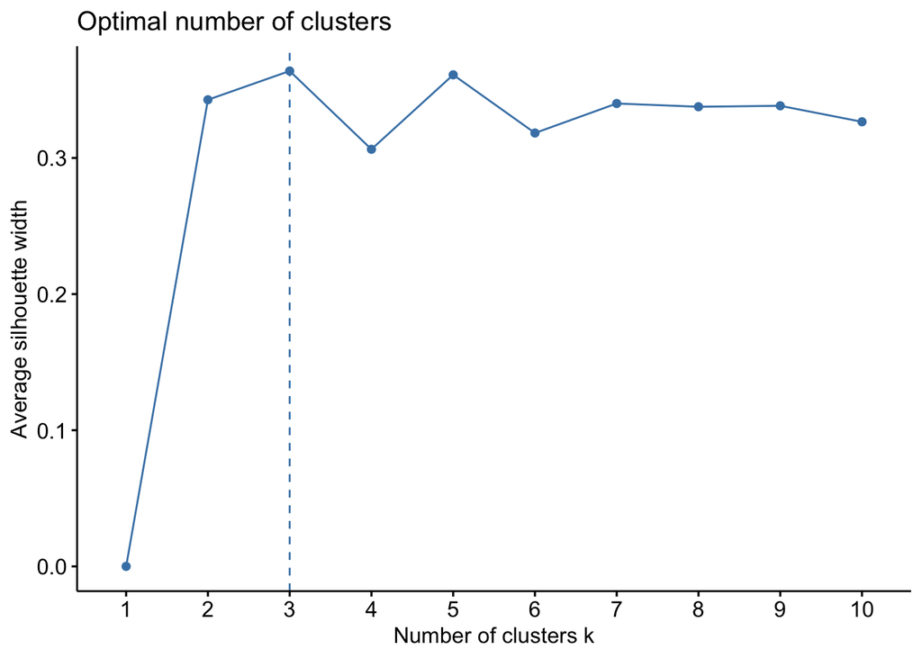

```r
# average silhouette for k clusters
fviz_nbclust(clust.data, kmeans, method = "silhouette")
```

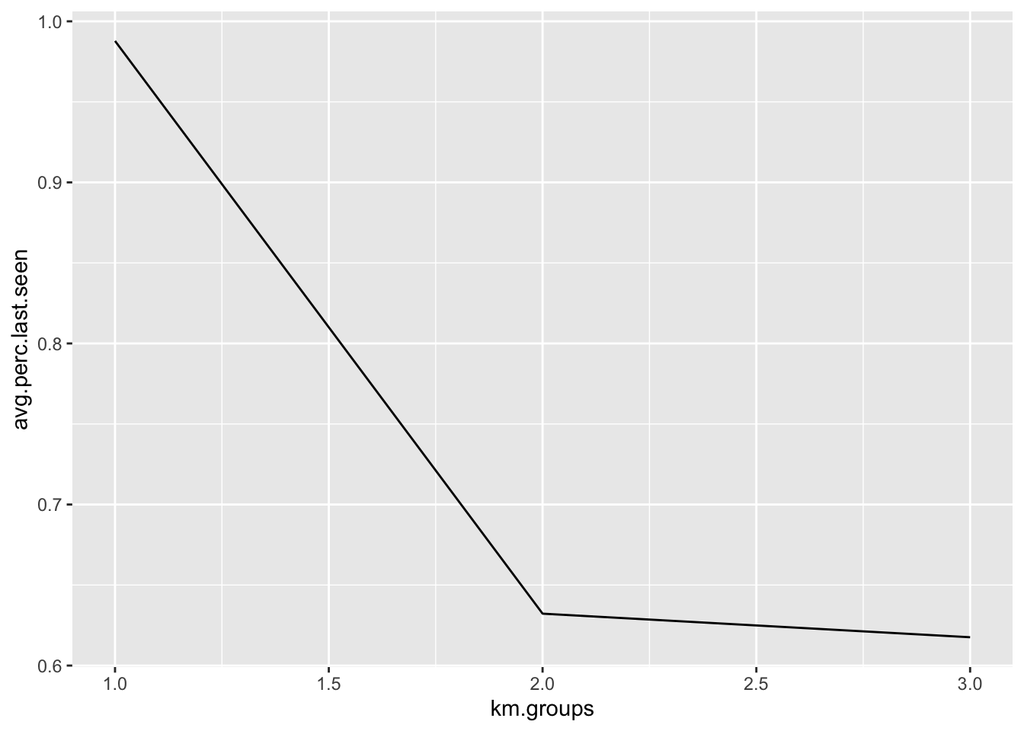

```r
set.seed(123456)
km.clusters <- kmeans(clust.data, centers = 3, nstart = 25)
frequency$km.groups <- km.clusters$cluster


agg.data <- frequency %>% group_by(km.groups) %>% summarise(avg.perc.last.seen = mean(perctentile.last.seen, na.rm = TRUE),
                                                             avg.last.seen.days = mean(last.seen.days, na.rm = TRUE),
                                                             avg.tenure = mean(tenure, na.rm = TRUE),
                                                             avg.total.freq = mean(num.freq, na.rm = TRUE))

ggplot(agg.data, aes(x=km.groups, y= avg.perc.last.seen)) +
  geom_line()
```

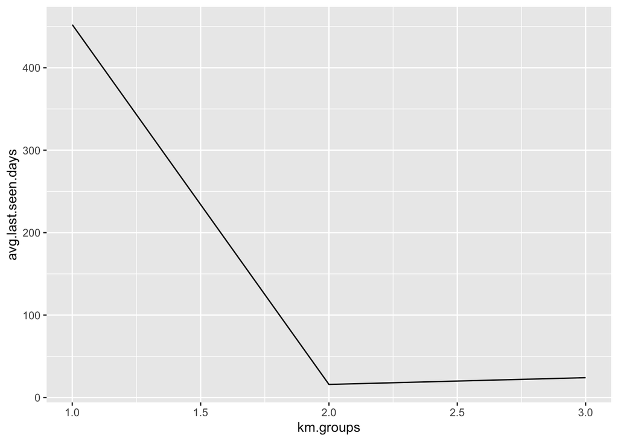

```r
ggplot(agg.data, aes(x=km.groups, y= avg.last.seen.days)) +
  geom_line()
```

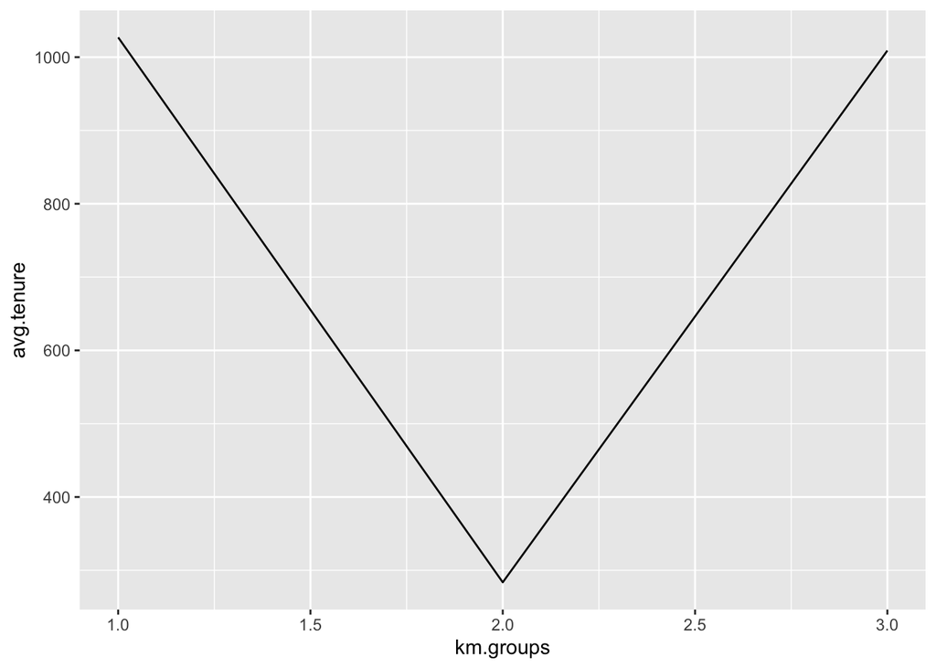

```r
ggplot(agg.data, aes(x=km.groups, y= avg.tenure)) +
  geom_line()
```

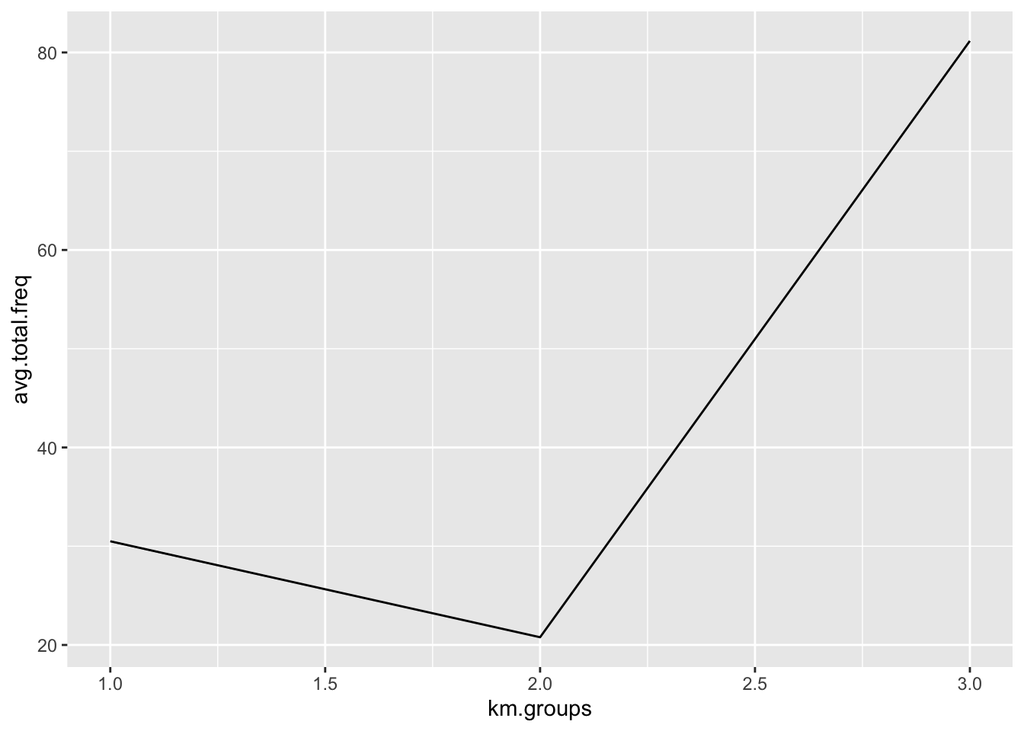

```r
ggplot(agg.data, aes(x=km.groups, y= avg.total.freq)) +
  geom_line()
```

### 4. Key Findings

- Results from Hierarchical Clustering, Meanshift, and K-means clusters suggests that there are 3 major clusters in the data
- Variables used for clustering:
  1. Percentile last seen: Percentile of Last seen days in the distribution of inter-arrival time of the customer
  2. Last seen days: Number of days from last activity till end of observation period
  3. Tenure: Number of days the ID was on the system in the observation period
  4. Total Freq: Number of activities in the observation peroid